# Project 3

Hendrik Orem, Ph.D., with thanks to Jameson Watts

03/16/2023

## Setup

```r
knitr::opts_chunk$set(echo = TRUE, message = FALSE, warning = FALSE)
library(tidyverse)
library(tidytext)
library(caret)
library(fastDummies)
library(randomForest)
# https://www.openml.org/d/1590

tourney_data <- read_csv("tourney_data.csv") %>%
  mutate(rank=log2(rank)) %>% # converts 1,2,4,8,16, etc to 0,1,2,3,4
  select(-Season,-class,-`Coach(es)`,-`NCAA Tournament`) %>% #either not helpful, or duplicative
  filter(!is.na(Pts_for)) %>% #removes 1 case
  mutate(across("AP Pre":"AP Final",function(x){ifelse(is.na(x),"Not 25",paste("Top",ceiling(x/5)*5))})) %>% #data cleaning
  mutate(across(Conf_W:Conf_Pct,function(x){ifelse(is.na(x),0,x)})) #%>% #fill missing info

skimr::skim(tourney_data)
```

Data summary

| Name | tourney_data |
| --- | --- |
| Number of rows | 2417 |
| Number of columns | 18 |
| _______________________ |  |
| Column type frequency: |  |
| character | 5 |
| numeric | 13 |
| ________________________ |  |
| Group variables | None |

**Variable type: character**

| skim_variable | n_missing | complete_rate | min | max | empty | n_unique | whitespace |
| --- | --- | --- | --- | --- | --- | --- | --- |
| Conf | 0 | 1 | 3 | 9 | 0 | 50 | 0 |
| AP Pre | 0 | 1 | 5 | 6 | 0 | 6 | 0 |
| AP High | 0 | 1 | 5 | 6 | 0 | 6 | 0 |
| AP Final | 0 | 1 | 5 | 6 | 0 | 6 | 0 |
| team | 0 | 1 | 26 | 54 | 0 | 305 | 0 |

**Variable type: numeric**

| skim_variable | n_missing | complete_rate | mean | sd | p0 | p25 | p50 | p75 | p100 | hist |
| --- | --- | --- | --- | --- | --- | --- | --- | --- | --- | --- |
| Ovr_W | 0 | 1 | 23.71 | 4.18 | 11.00 | 21.00 | 23.00 | 26.00 | 38.00 | ▁▅▇▂▁ |
| Ovr_L | 0 | 1 | 9.33 | 3.04 | 1.00 | 7.00 | 9.00 | 11.00 | 21.00 | ▂▇▇▂▁ |
| Ovr_Pct | 0 | 1 | 0.72 | 0.09 | 0.37 | 0.65 | 0.71 | 0.78 | 0.97 | ▁▂▇▆▂ |
| Conf_W | 0 | 1 | 11.75 | 2.71 | 0.00 | 10.00 | 12.00 | 14.00 | 20.00 | ▁▂▇▆▁ |
| Conf_L | 0 | 1 | 4.70 | 2.40 | 0.00 | 3.00 | 5.00 | 6.00 | 13.00 | ▃▇▅▂▁ |
| Conf_Pct | 0 | 1 | 0.71 | 0.15 | 0.00 | 0.61 | 0.72 | 0.81 | 1.00 | ▁▁▃▇▅ |
| SRS | 0 | 1 | 11.20 | 8.09 | -17.11 | 6.74 | 12.57 | 16.71 | 34.79 | ▁▃▇▇▁ |
| SOS | 0 | 1 | 4.00 | 5.75 | -14.17 | -0.28 | 5.84 | 8.52 | 14.32 | ▁▃▃▇▅ |
| Pts_for | 0 | 1 | 75.23 | 6.20 | 57.90 | 71.10 | 74.80 | 78.80 | 122.40 | ▃▇▁▁▁ |
| Pts_against | 0 | 1 | 67.45 | 5.61 | 48.20 | 63.80 | 67.30 | 70.60 | 108.10 | ▁▇▂▁▁ |
| Seed | 0 | 1 | 8.70 | 4.64 | 1.00 | 5.00 | 9.00 | 13.00 | 16.00 | ▇▆▆▆▇ |
| tourn_year | 0 | 1 | 2004.02 | 11.14 | 1985.00 | 1994.00 | 2004.00 | 2014.00 | 2023.00 | ▇▇▇▇▇ |
| rank | 0 | 1 | 5.05 | 1.32 | 0.00 | 5.00 | 6.00 | 6.00 | 6.00 | ▁▁▁▁▇ |

```r
tourney_data2<-tourney_data %>%
  fastDummies::dummy_cols(remove_selected_columns = T) %>% #simple dummy cols
  arrange(tourn_year) %>% mutate(lag_rank=lag(rank)) %>% mutate(lag_rank=ifelse(is.na(lag_rank),6,lag_rank)) %>% #how did the team do last year
  mutate(rank=as.numeric(rank<=4))# <=4 = Did team make the sweet 16 (one of the final 2^4 teams)
table(tourney_data2$rank)
```

```
##
##    0    1
## 1834  583
```

## Some questions about the data

Please try at least a few of the following:

- Run PCA on the dataset. How many principal components do you need to explain half the variation?
- Can you give some interpretation of the principal components?
- Look at the scree plot. How many PCs would you choose based on that?
- Are the first few Principal Components good predictors of income_above_50k?
- How well can you predict income_above_50k using the first 5 or 6 principal components? How about only the first 2?
- Can you gain any insights into the data based on k-means clustering?
- Can you visualize and interpret some or all of your clusters?
- Using any and all techniques we have learned, build the best predictive model for income_above_50k that you can. What are your best features? What model did you use? What interpretations can you draw?
- What metric can you use to assess model performance? Why is that a good choice of metric in this case?
- What are some key insights you found through your analysis?

Please remember: a statement like “PC2 is not a meaningful predictor for our modeling problem” is a great insight; sometimes things don’t work!

10 pts PCA

- analysis and interpretation of factor loadings
- discussion of scree plot and/or analysis of some density plots of PCs
- the screeplot suggests that the proper number of principle components is 3.
- meaningful interpretation / discussion of conclusions
- PC1 is correlated with strength of record and inversely with seed (corelated with better seeds) mean that PC1 represents the best seeded teams who also performed well throughout the year.
- PC2 is inversely correlated with conference win percentage (as well as conference wins and losses). This indicates teams that struggled in conference.
- PC3 is inversely correlated with both points for and points against suggest that these are teams with strong defenses but poor offenses.

```r
pr_tourney <- prcomp(x = select(tourney_data2,-rank), scale = T, center = T)
summary(pr_tourney)
```

```
## Importance of components:
##                            PC1     PC2     PC3     PC4     PC5     PC6     PC7
## Standard deviation     2.90504 2.26495 1.68939 1.55194 1.47048 1.46257 1.44557
## Proportion of Variance 0.02186 0.01329 0.00739 0.00624 0.00560 0.00554 0.00541
## Cumulative Proportion  0.02186 0.03515 0.04255 0.04879 0.05439 0.05993 0.06534
##                            PC8     PC9    PC10    PC11    PC12    PC13    PC14
## Standard deviation     1.44080 1.43508 1.43273 1.42850 1.42262 1.42065 1.41947
## Proportion of Variance 0.00538 0.00534 0.00532 0.00529 0.00524 0.00523 0.00522
## Cumulative Proportion  0.07072 0.07606 0.08138 0.08666 0.09191 0.09713 0.10235
##                          PC15    PC16    PC17    PC18    PC19    PC20    PC21
## Standard deviation     1.4167 1.41464 1.41424 1.40960 1.40906 1.40732 1.40474
## Proportion of Variance 0.0052 0.00518 0.00518 0.00515 0.00514 0.00513 0.00511
## Cumulative Proportion  0.1076 0.11274 0.11792 0.12307 0.12821 0.13334 0.13845
##                          PC22    PC23    PC24    PC25    PC26    PC27    PC28
## Standard deviation     1.4029 1.40113 1.39223 1.39116 1.38378 1.37969 1.37264
## Proportion of Variance 0.0051 0.00509 0.00502 0.00501 0.00496 0.00493 0.00488
## Cumulative Proportion  0.1436 0.14864 0.15366 0.15867 0.16363 0.16857 0.17345
##                           PC29    PC30    PC31    PC32    PC33    PC34    PC35
## Standard deviation     1.35966 1.35520 1.35339 1.33939 1.33847 1.32000 1.30681
## Proportion of Variance 0.00479 0.00476 0.00475 0.00465 0.00464 0.00451 0.00442
## Cumulative Proportion  0.17824 0.18299 0.18774 0.19239 0.19703 0.20154 0.20597
##                           PC36    PC37    PC38    PC39    PC40    PC41    PC42
## Standard deviation     1.30241 1.29691 1.28701 1.28011 1.27673 1.26865 1.25712
## Proportion of Variance 0.00439 0.00436 0.00429 0.00425 0.00422 0.00417 0.00409
## Cumulative Proportion  0.21036 0.21472 0.21901 0.22326 0.22748 0.23165 0.23574
##                           PC43    PC44   PC45    PC46    PC47    PC48   PC49
## Standard deviation     1.25024 1.24641 1.2270 1.22403 1.21977 1.21380 1.1958
## Proportion of Variance 0.00405 0.00402 0.0039 0.00388 0.00385 0.00382 0.0037
## Cumulative Proportion  0.23979 0.24382 0.2477 0.25160 0.25545 0.25927 0.2630
##                           PC50    PC51   PC52    PC53    PC54    PC55   PC56
## Standard deviation     1.19218 1.18889 1.1795 1.16438 1.16058 1.15051 1.1462
## Proportion of Variance 0.00368 0.00366 0.0036 0.00351 0.00349 0.00343 0.0034
## Cumulative Proportion  0.26666 0.27032 0.2739 0.27743 0.28092 0.28435 0.2878
##                           PC57    PC58    PC59    PC60    PC61    PC62    PC63
## Standard deviation     1.13060 1.12239 1.11450 1.10526 1.08840 1.08172 1.06460
## Proportion of Variance 0.00331 0.00326 0.00322 0.00316 0.00307 0.00303 0.00294
## Cumulative Proportion  0.29107 0.29433 0.29755 0.30071 0.30378 0.30681 0.30975
##                           PC64    PC65    PC66   PC67    PC68    PC69    PC70
## Standard deviation     1.06245 1.04747 1.03859 1.0205 1.01736 1.01339 1.01118
## Proportion of Variance 0.00292 0.00284 0.00279 0.0027 0.00268 0.00266 0.00265
```

[output cut: 162 more lines]

```
## Standard deviation     0.20795 0.1987 0.18610 0.18033 0.17264 0.15863 0.14727
## Proportion of Variance 0.00011 0.0001 0.00009 0.00008 0.00008 0.00007 0.00006
## Cumulative Proportion  0.99931 0.9994 0.99951 0.99959 0.99967 0.99973 0.99979
##                          PC369   PC370   PC371   PC372   PC373   PC374   PC375
## Standard deviation     0.13338 0.11946 0.11307 0.10465 0.08743 0.07931 0.07403
## Proportion of Variance 0.00005 0.00004 0.00003 0.00003 0.00002 0.00002 0.00001
## Cumulative Proportion  0.99984 0.99987 0.99991 0.99993 0.99995 0.99997 0.99998
##                          PC376   PC377     PC378     PC379     PC380     PC381
## Standard deviation     0.05561 0.05413 3.369e-15 1.512e-15 1.261e-15 1.218e-15
## Proportion of Variance 0.00001 0.00001 0.000e+00 0.000e+00 0.000e+00 0.000e+00
## Cumulative Proportion  0.99999 1.00000 1.000e+00 1.000e+00 1.000e+00 1.000e+00
##                            PC382     PC383     PC384     PC385     PC386
## Standard deviation     1.133e-15 1.096e-15 1.075e-15 1.029e-15 1.013e-15
## Proportion of Variance 0.000e+00 0.000e+00 0.000e+00 0.000e+00 0.000e+00
## Cumulative Proportion  1.000e+00 1.000e+00 1.000e+00 1.000e+00 1.000e+00
```

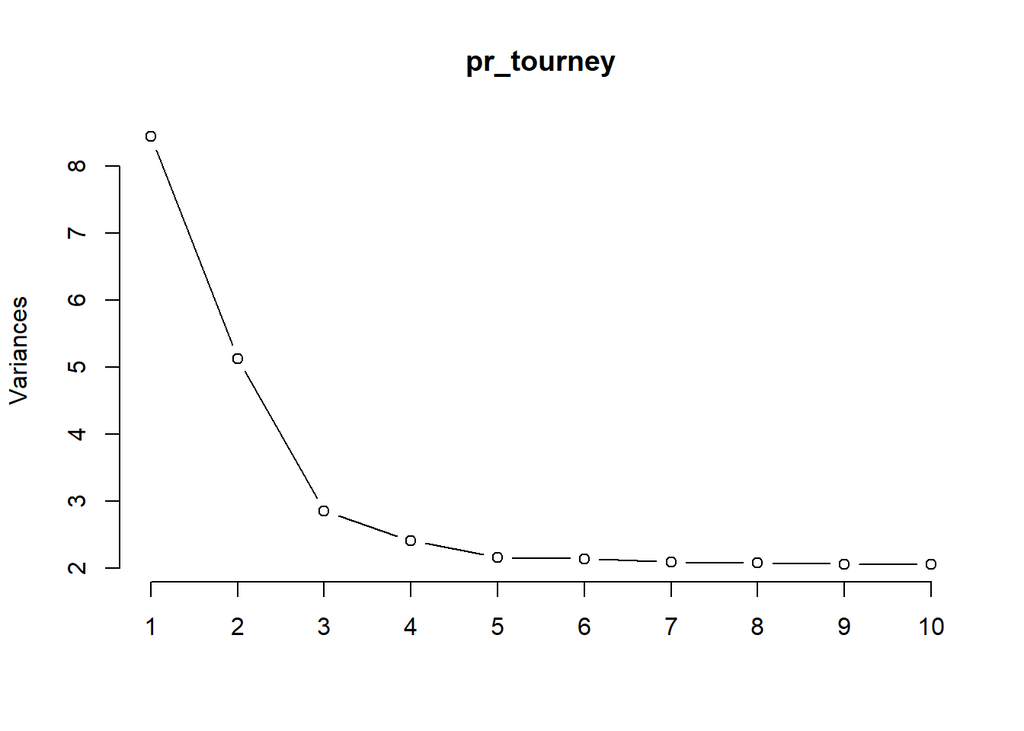

```r
screeplot(pr_tourney, type = "lines")
```

```r
rownames_to_column(as.data.frame(pr_tourney$rotation)) %>%
  select(1:4) %>%
  filter(abs(PC1) >= 0.25 | abs(PC2) >= 0.25 | abs(PC3) >= 0.25) %>%
  View()

prc <- bind_cols(select(tourney_data2,rank),as.data.frame(pr_tourney$x)) %>%
  select(1:4) %>%
  rename("strong_record_seed" = PC1) %>%
  rename("struggle_in_conf" = PC2) %>%
  rename("defense_focus" = PC3)
head(prc)
```

| rank | strong_record_seed | struggle_in_conf | defense_focus |
| --- | --- | --- | --- |
| 1 | -0.8887097 | 1.3669218 | 0.59103173 |
| 0 | -0.4470477 | 0.7665369 | 0.33380127 |
| 0 | -0.5611517 | 2.3423655 | -0.06879977 |
| 1 | -1.9522438 | 2.9207931 | -0.39989682 |
| 1 | -1.4490541 | 3.4623182 | 0.20244364 |
| 0 | -2.9259237 | 3.3204769 | 0.10399192 |

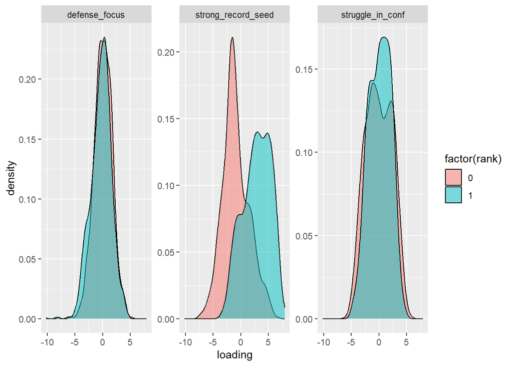

```r
prc %>%
  pivot_longer(cols = -rank,names_to = "component",values_to = "loading") %>%
  ggplot(aes(x=loading, fill=factor(rank),group=rank))+
  geom_density(alpha=0.5)+
  facet_wrap(.~component,scales = "free_y")
```

10 pts k-means